# Machine Learning - PEC3

Miguel Ocaña Acosta

13/01/2021

En esta PEC se ha desarrollado un script reutilizable para cualquier fichero de datos con promotores tal y como se estructuran en el archivo de este problema (*promoters.txt*). Para ello, se ha fragmentado las diferentes partes del código en funciones, que se irán explicando a lo largo del trabajo. La única pega es que no se graficará al final (apartado Discusión), algo pendiente de añadir en el futuro. Para utilizarlo con otros datos, se requiere cumplir una serie de condiciones:

1. El *dataframe* debe estar formado por dos columnas:
- la variable dependiente (el promotor).
- la secuencia de nucleótidos.
2. La **variable dependiente** debe:
- Situarse en la primera columna.
- Ser de tipo carácter (`as.character()`).
- Estar formada por *+* o *-*.
3. Las **secuencias de nucleótidos** deben:
- Situarse en la última columna.
- Ser de tipo carácter.
- Tener el mismo tamaño.
- Estar formadas por A, G, T o C (mayúsculas o minúsculas).

Por ejemplo:

```r
data.frame(promoter=c('+','-','+','-','-','+'),seq=c('agtt','ACTG','GCTA','actg','gtca','ccct'))
```

```
##   promoter  seq
## 1        + agtt
## 2        - ACTG
## 3        + GCTA
## 4        - actg
## 5        - gtca
## 6        + ccct
```

# Consideraciones de la PEC

**1.** Implementar una función para realizar una transformación one-hot encoding de las secuencias del fichero de datos promoters.txt. En caso de no lograr la implementaación de dicha transformación, se puede utilizar el fichero promoters_onehot.txt con las secuencias codificados segun un one-hot para completar la actividad.

**2.** En cada algoritmo hay que realizar las siguientes etapas: 1) Entrenar el modelo 2) Predicción y Evaluacióndel algoritmo. Será necesario “tunear” diferentes valores de los hiperparámetros del algoritmo paraposteriormente evaluar su rendimiento.

**3.** Se debe aplicar la misma selección de datos training y test en todos los algoritmos. Utilizando la semilla aleatoria 123, para separar los datos en dos partes, una parte para training (67%) y otra partepara test (33%). Opcionalmente, se puede escoger otro tipo de partición del conjunto de training parahacer la validación como por ejemplo k-fold crossvalidation, boostrap, random splitting, etc. Lo que esimportante es mantener la misma selección para todos los algoritmos.

**4.** En todos los casos se evalua la calidad del algoritmo con la información obtenida de la funciónconfusionMatrix() del paquete caret.

**5.** Para la ejecución especifica de cada algoritmo se puede usar la función de cada algoritmo como sepresenta en el libro de referencia o usar el paquete caret con los diferentes modelos de los algoritmos. O incluso, hacer una versión mixta.

# Transformación de los datos

## Importar los datos

En primer lugar, se importan los datos con los que se va a trabajar. El fichero *promoters.txt* no viene con cabecera (`header`) y está separada por comas (`sep`). Al mismo tiempo, se estudian brevemente los mismos:

```r
# definir aquí tu csv
promoters <- read.csv('promoters.txt',header = FALSE,sep=',') # se importan
str(promoters) # se estudian
```

```
## 'data.frame':    105 obs. of  3 variables:
##  $ V1: chr  "+" "+" "+" "+" ...
##  $ V2: chr  "S10" "AMPC" "AROH" "DEOP2" ...
##  $ V3: chr  "tactagcaatacgcttgcgttcggtggttaagtatgtataatgcgcgggcttgtcgt" "tgctatcctgacagttgtcacgctgattggtgtcgttacaatctaacgcatcgccaa" "gtactagagaactagtgcattagcttatttttttgttatcatgctaaccacccggcg" "aattgtgatgtgtatcgaagtgtgttgcggagtagatgttagaatactaacaaactc" ...
```

En los modelos que se van a utilizar, no es necesario usar más que la etiqueta del promotor y la secuencia de nucleótidos. Por eso se puede omitir la segunda columna, que corresponde al nombre de la secuencia promotora.

```r
promoters2 <- promoters[,-2]
```

A partir de aquí, la idea de clasificar las secuencias con X tamaño consiste en entrenar modelos que estudian la posición y el nucleótido que lo ocupa. Por eso es importante que las secuencias compartan el mismo tamaño (o al menos en este caso), porque el procesamiento que se va a llevar a cabo de los datos tratará principalmente de dividir cada posición como una columna diferente dentro del *dataframe*. Para ello, sufrirán dos transformaciones diferentes:

- Por un lado, el **one-hot encoding**, que codificará los nucleótidos en secuencias de 1 y 0 siguiendo esta regla:
  - T = (1,0,0,0)
  - C = (0,1,0,0)
  - G = (0,0,1,0)
  - A = (0,0,0,1)

Como cada nucleótido se codifica en 4 dígitos diferentes, se crea una columna por cada nucleótido multiplicado por 4. En este problema las secuencias se conforman de 57 nucleótidos, por tanto:

$n_{columnas} = 57*4 = 228$

- Por otro lado, uno de los modelos que se va a utilizar es Naïve Bayes, que trabaja con valores de entrenamiento **categóricos**, y bastará con dividir cada nucleótido en una columna diferente.

En el resto de apartados, se mostrará en primer lugar la función y a continuación se desglosará para ir explicando paso a paso cómo trabaja.

## One-Hot Encoding

Valores de entrada:

- `df`: *dataframe* con la etiqueta de promotor y su secuencia.
- `col_seq`: nombre (de tipo carácter) de la columna con la secuencia de nucleótidos.
- `onehot_cols_name`: prefijo que asignará la función a cada columna que cree, por defecto **H**.
- `remove_col_seq`: opción para eliminar la columna con la secuencia tras la codificación, por defecto `TRUE`.

```r
onehot <- function (df, col_seq, onehot_cols_name='H', remove_col_seq = TRUE) {
  # Se asegura de que todas las seq tengan el mismo tama?o (de lo contrario salta ERROR)
  f <- length(strsplit(df[col_seq][[1]], "")[[1]])
  for (j in 1:nrow(df)) {
    a = length(strsplit(df[j,col_seq], "")[[1]])
    if (a == f) {
      next
    } else {
      print('ERROR: al menos una secuencia no tiene el mismo tama?o que el resto.')
      break
    }
  }

  # Crea una columna por cada d?gito del one-hot
  num_cols <- f * 4
  cols_onehot <- list()
  for (i in 1:num_cols) {
    cols_onehot <- append(cols_onehot,paste(onehot_cols_name,i,sep=""))
  }

  # A?ade las columnas (vac?as) al nuevo DF
  df2 <- df
  for (i in cols_onehot) {
    df2[,i] <- NA
  }

  # Traducci?n de seq a one-hot encoding
  for (j in 1:nrow(df2)) {
    seq = strsplit(tolower(df2[j,col_seq]), "")[[1]] # convierte la seq en minuscula
    seq_onehot <- list()
    for (i in seq) {
      if (i == 'a') {
        seq_onehot <- append(seq_onehot, c(0,0,0,1))
      } else if (i == 'g') {
        seq_onehot <- append(seq_onehot, c(0,0,1,0))
      } else if (i == 'c') {
        seq_onehot <- append(seq_onehot, c(0,1,0,0))
      } else if (i == 't') {
        seq_onehot <- append(seq_onehot, c(1,0,0,0))
      } else {
        print("ERROR: al menos un car?cter de la secuencia introducida no corresponde a ning?n nucle?tido (A,G,C,T).")
        break
      }
    }
    for (k in 1:length(seq_onehot)) {
      ind <- grep(paste(onehot_cols_name,k,sep=""), colnames(df2))
      df2[j,ind] <- seq_onehot[k]
    }
  }

  # Elimina o no la columna con la secuencia
  if (remove_col_seq) {
    df3 <- df2[,c(colnames(df2)[-grep(col_seq, colnames(df2))])]
  } else {
    df3 <- df2
  }

  # Devuelve el df con one-hot encoding
  return (df3)
}
```

**Cómo funciona**

Primero, guarda el tamaño de la primera secuencia, que utiliza como referencia para el tamaño y compara con el resto de secuencias. Se asegura de que todas tengan el mismo tamaño, de lo contrario, lanza un error.

```r
f <- length(strsplit(df[col_seq][[1]], "")[[1]])  # coge el tamaño
for (j in 1:nrow(df)) {                           # bucle para asegurar tamaño equitativo
  a = length(strsplit(df[j,col_seq], "")[[1]])
  if (a == f) {
    next
  } else {
    print('ERROR: al menos una secuencia no tiene el mismo tama?o que el resto.')
    break
  }
}
```

Si todo cumple, multiplica por 4 la variable que se guardó con el tamaño de la secuencia y genera ese número de nombres con el prefijo que se haya establecido (`onehot_cols_name`) + posición, guardándolos en una lista.

```r
num_cols <- f * 4       # número de columnas
cols_onehot <- list()   # lista vacía para unir nombres en bucle
for (i in 1:num_cols) { # bucle para unir los nombres generados
  cols_onehot <- append(cols_onehot,paste(onehot_cols_name,i,sep=""))
}
```

Crea una columna vacía por cada nombre que haya en la lista creada anteriormente. Además, asigna en una variable `df2` el *dataframe*. Se consideran buenas prácticas cuando se trabaja demasiado un *dataframe* y en algún momento se quiera volver atrás.

```r
df2 <- df
for (i in cols_onehot) {
  df2[,i] <- NA
}
```

La codificación ocurre con 3 bucles. En primer lugar, recorre cada fila del *dataframe* para guardar en una variable la secuencia de la columna establecida en los parámetros de la función (`col_seq`) y convertirla en minúsculas (`tolower()`). En esta variable se guarda como una lista con los nucleótidos separados (`strsplit()`).

```r
for (j in 1:nrow(df2)) {
  seq = strsplit(tolower(df2[j,col_seq]), "")[[1]]
  seq_onehot <- list()
```

En ese punto del bucle, crea una lista vacía a la que se irán uniendo los nucleótidos codificados en *one-hot*, siguiendo las reglas que especificamos. Empieza otro bucle por cada nucleótido de la lista creada anteriormente que irá codificando, y si alguna posición no correspondiera a un nucleótido, lanza error.

```r
  seq_onehot <- list()  # lista vacía para unir nucleótidos codificados
  for (i in seq) {
    if (i == 'a') {     # serie de condiciones para el one-hot
      seq_onehot <- append(seq_onehot, c(0,0,0,1))
    } else if (i == 'g') {
      seq_onehot <- append(seq_onehot, c(0,0,1,0))
    } else if (i == 'c') {
      seq_onehot <- append(seq_onehot, c(0,1,0,0))
    } else if (i == 't') {
      seq_onehot <- append(seq_onehot, c(1,0,0,0))
    } else {
      print("ERROR: al menos un car?cter de la secuencia introducida no corresponde a ning?n nucle?tido (A,G,C,T).")
      break
    }
  }
  for (k in 1:length(seq_onehot)) { # el siguiente bucle
```

Dentro aún del bucle de la fila, termina con otro que busca el nombre de la columna (`grep()`, expresión regular igual que en *bash*) para encontrar su índice e ir pegando en cada una el valor de la codificación.

```r
  for (k in 1:length(seq_onehot)) { # empieza el bucle sobre el tamaño de la secuencia codificada
    ind <- grep(paste(onehot_cols_name,k,sep=""), colnames(df2))
    df2[j,ind] <- seq_onehot[k]     # asigna el valor de la codificación a la posición
  }
```

Terminada la codificación, se añadió una *feature* que permite eliminar o no la columna original, en un principio para comprobar si la codificación es correcta.

```r
# Elimina o no la columna con la secuencia
if (remove_col_seq) {
  df3 <- df2[,c(colnames(df2)[-grep(col_seq, colnames(df2))])]
} else {
  df3 <- df2
}
```

## Transformación de categóricos

Valores de entrada:

- `df`: *dataframe* con la etiqueta de promotor y su secuencia.
- `col_seq`: nombre (de tipo carácter) de la columna con la secuencia de nucleótidos.
- `sepseq_cols_name`: prefijo que asignará la función a cada columna que cree, por defecto **N**.
- `remove_col_seq`: opción para eliminar la columna con la secuencia tras la codificación, por defecto `TRUE`.

```r
sepseq <- function (df, col_seq, sepseq_cols_name='N', remove_col_seq = TRUE) {
  f <- length(strsplit(df[col_seq][[1]], "")[[1]])
  for (j in 1:nrow(df)) {
    a = length(strsplit(df[j,col_seq], "")[[1]])
    if (a == f) {
      next
    } else {
      print('ERROR: al menos una secuencia no tiene el mismo tama?o que el resto.')
      break
    }
  }
  num_cols <- f
  cols_sepseq <- list()
  for (i in 1:num_cols) {
    cols_sepseq <- append(cols_sepseq,paste(sepseq_cols_name,i,sep=""))
  }

  df2 <- df
  for (i in cols_sepseq) {
    df2[,i] <- NA
  }

  for (j in 1:nrow(df2)) { # ----------------------- ÚNICA DIFERENCIA
    seq = strsplit(tolower(df2[j,col_seq]), "")[[1]]
    seq_sepseq <- list()
    for (i in seq) {
      if ((i == 'a') | (i == 'g') | (i == 'c') | (i == 't')) {
        seq_sepseq <- append(seq_sepseq, i)
      } else {
        print("ERROR: al menos un car?cter de la secuencia introducida no corresponde a ning?n nucle?tido (A,G,C,T).")
        break
      }
    }
    for (k in 1:length(seq_sepseq)) {
      ind <- grep(paste(sepseq_cols_name,k,sep=""), colnames(df2))
      df2[j,ind] <- seq_sepseq[k]
    }
  }

  if (remove_col_seq) {
    df3 <- df2[,c(colnames(df2)[-grep(col_seq, colnames(df2))])]
  } else {
    df3 <- df2
  }

  return (df3)
}
```

**Cómo funciona**

La función es prácticamente igual que la anterior, con la única diferencia en el bucle de codificación. Aquí el bucle recorre lo mismo, pero en vez de codificar, guarda los nucleótidos como están y los utiliza para asignarlos a las diferentes columnas.

```r
  for (j in 1:nrow(df2)) {    # ----------------------- ÚNICA DIFERENCIA
    seq = strsplit(tolower(df2[j,col_seq]), "")[[1]]
    seq_sepseq <- list()
    for (i in seq) {
      if ((i == 'a') | (i == 'g') | (i == 'c') | (i == 't')) {
        seq_sepseq <- append(seq_sepseq, i)
      } else {
        print("ERROR: al menos un car?cter de la secuencia introducida no corresponde a ning?n nucle?tido (A,G,C,T).")
        break
      }
    }
    for (k in 1:length(seq_sepseq)) {
      ind <- grep(paste(sepseq_cols_name,k,sep=""), colnames(df2))
      df2[j,ind] <- seq_sepseq[k]
    }
  }
```

## Otras funciones

Estas son otras funciones útiles que han sido necesarias para el funcionamiento del *script*.

### División de datos en train y test

Divide aleatoriamente el *dataframe* en *train* y *test*. Valores de entrada:

- `df`: el *dataframe*.
- `size`: proporción de la división, en concreto para *train*, el resto de *test*.
- `seed`: la semilla que se establece para la división, por defecto `123`.

```r
split_train_test <- function(df, size = 0.7, seed = 123) {
  # Establece la semilla
  set.seed(seed)

  # Devuelve un "diccionario" con el DF partido en train y test
  t <- floor(size * nrow(df))
  train_ind <- sample(seq_len(nrow(df)), size = t)
  train <- df[train_ind,]
  test <- df[-train_ind,]

  # Quita la semilla
  set.seed(Sys.time())

  return (list('train' = train, 'test' = test))
}
```

### Transformación de promotor numérico - factor

Función que se ha creado para el algoritmo *Artificial Neural Network*, pues necesita valores numéricos en la variable dependiente.

```r
num_to_cat <- function (vector) {
  # Está pensada para la variable dependiente,
  # la primera columna debe ser la clase.
  # Transforma los promotores en factores + (1) y - (0).
  for (i in 1:length(vector)) {
    if (vector[i]==1) {
      vector[i] <- '+'
    } else {
      vector[i] <- '-'
    }
  }
  vector <- as.factor(vector)
  return (vector)
}
```

### Transformación de promotor factor - numérico

```r
cat_to_num <- function (vector) {
  # Está pensada para la variable dependiente,
  # la primera columna debe ser la clase.
  # Transforma los promotores en 1 (+) y 0 (-).
  for (i in 1:length(vector)) {
    if (vector[i]=='+') {
      vector[i] <- 1
    } else {
      vector[i] <- 0
    }
  }
  vector <- as.numeric(vector)
  return (vector)
}
```

# Clasificación de los datos

Todas las funciones creadas para los modelos engloban entrenamiento y predicción, pues están pensadas para hacernos una idea global de cómo se comportan frente a diferentes conjuntos de datos pequeños, en este caso los promotores y sus secuencias.

En esta parte del *workflow*, es necesario recordar y ajustar los parámetros necesarios:

- `df_onehot`: el *dataframe* codificado en *one-hot encoding*.
- `df_categorico`: el *dataframe* con los nucleótidos divididos en columnas.
- `formula`: fórmula necesaria para los modelos *Support Vector Machine* y *Artifical Neural Network*, como veremos más adelante.

Los definimos todos con las funciones que hemos creado hasta ahora:

```r
# definir aquí tu DF (del csv importado) y columna con secuencia
df_onehot <- onehot(df = promoters2, col_seq = 'V3')
df_categorico <- sepseq(df = promoters2, col_seq = 'V3')
formula <- V1 ~ .
```

Además, cargamos la librería para la matriz de confusión, que se utilizará en todos los casos:

```r
library('caret')
```

Como veníamos haciendo anteriormente, primero se adjuntará la función del modelo que se ha creado, y se explicarán sus partes antes de entrar en *Entrenar el modelo* y *Predicción y Evaluación*.

## k-Nearest Neighbour

**Condición**: se explorarán los valores para el número de vecinos k = 1,3,5,7.

Librería utilizada:

```r
library('class')
```

Variables de entrada:

- `df_onehot`: el *dataframe* codificado en *one-hot encoding*.

```r
kneighbors <- function(df_onehot) {

  # Split train y data
  train <- split_train_test(df_onehot)$train[,-1]
  test <- split_train_test(df_onehot)$test[,-1]
  train_labels <- as.factor(split_train_test(df_onehot)$train[,1])
  test_labels <- as.factor(split_train_test(df_onehot)$test[,1])

  # kNN 1
  # Modelo y estad?sticos
  knn1 <- knn(train = train, test = test, cl = train_labels, k = 1)
  # Predicciones
  kneighbors_1_p <- confusionMatrix(knn1, test_labels, dnn = c('Predicho','Actual'))

  # kNN 3
  # Modelo y estad?sticos
  knn3 <- knn(train = train, test = test, cl = train_labels, k = 3)
  # Predicciones
  kneighbors_3_p <- confusionMatrix(knn3, test_labels, dnn = c('Predicho','Actual'))

  # kNN 5
  # Modelo y estad?sticos
  knn5 <- knn(train = train, test = test, cl = train_labels, k = 5)
  # Predicciones
  kneighbors_5_p <- confusionMatrix(knn5, test_labels, dnn = c('Predicho','Actual'))

  # kNN 7
  # Modelo y estad?sticos
  knn7 <- knn(train = train, test = test, cl = train_labels, k = 7)
  # Predicciones
  #kneighbors_7_p <- CrossTable(x = test_labels, y = knn7, prop.chisq=FALSE)
  kneighbors_7_p <- confusionMatrix(knn7, test_labels, dnn = c('Predicho','Actual'))

  return (list('k1'=kneighbors_1_p,'k3'=kneighbors_3_p,'k5'=kneighbors_5_p,'k7'=kneighbors_7_p))
}
```

**Cómo funciona**

Se separa el *dataframe* en *train* y *test* con nuestra función. Además, para este modelo es necesario separar las etiquetas, es decir, las variables dependientes.

```r
  train <- split_train_test(df_onehot)$train[,-1]
  test <- split_train_test(df_onehot)$test[,-1]
  train_labels <- as.factor(split_train_test(df_onehot)$train[,1])
  test_labels <- as.factor(split_train_test(df_onehot)$test[,1])
```

En el modelo de esta librería el entrenamiento y predicción ocurren al mismo tiempo, es decir, nos devuelve la predicción de los valores que utilizará para la matriz de confusión.

```r
  knn1 <- knn(train = train, test = test, cl = train_labels, k = 1)
```

Guarda en una variable el resultado de la matriz de confusión.

```r
  kneighbors_1_p <- confusionMatrix(knn1, test_labels)
```

Estos dos últimos pasos se repiten tres veces más cambiando el número de vecino `k` a 3, 5 y 7.

### Entrenamiento del modelo

```r
KNN <- kneighbors(df_onehot)
```

### Predicción y evaluación

**kNN con k = 1**

```r
KNN$k1
```

```
## Confusion Matrix and Statistics
##
##         Actual
## Predicho  -  +
##        -  9  1
##        +  6 16
##
##                Accuracy : 0.7812
##                  95% CI : (0.6003, 0.9072)
##     No Information Rate : 0.5312
##     P-Value [Acc > NIR] : 0.00318
##
##                   Kappa : 0.552
##
##  Mcnemar's Test P-Value : 0.13057
##
##             Sensitivity : 0.6000
##             Specificity : 0.9412
##          Pos Pred Value : 0.9000
##          Neg Pred Value : 0.7273
##              Prevalence : 0.4688
##          Detection Rate : 0.2812
##    Detection Prevalence : 0.3125
##       Balanced Accuracy : 0.7706
##
##        'Positive' Class : -
##
```

**kNN con k = 3**

```r
KNN$k3
```

```
## Confusion Matrix and Statistics
##
##         Actual
## Predicho  -  +
##        - 11  2
##        +  4 15
##
##                Accuracy : 0.8125
##                  95% CI : (0.6356, 0.9279)
##     No Information Rate : 0.5312
##     P-Value [Acc > NIR] : 0.0009089
##
##                   Kappa : 0.6206
##
##  Mcnemar's Test P-Value : 0.6830914
##
##             Sensitivity : 0.7333
##             Specificity : 0.8824
##          Pos Pred Value : 0.8462
##          Neg Pred Value : 0.7895
##              Prevalence : 0.4688
##          Detection Rate : 0.3438
##    Detection Prevalence : 0.4062
##       Balanced Accuracy : 0.8078
##
##        'Positive' Class : -
##
```

Interpretación de los resultados con un *test* de 32 secuencias:

- Buena
- El modelo tiene una precisión del 81%
- Devuelve 4 falsos positivos
- Devuelve 2 falsos negativos

**kNN con k = 5**

```r
KNN$k5
```

```
## Confusion Matrix and Statistics
##
##         Actual
## Predicho  -  +
##        -  8  2
##        +  7 15
##
##                Accuracy : 0.7188
##                  95% CI : (0.5325, 0.8625)
##     No Information Rate : 0.5312
##     P-Value [Acc > NIR] : 0.02417
##
##                   Kappa : 0.424
##
##  Mcnemar's Test P-Value : 0.18242
##
##             Sensitivity : 0.5333
##             Specificity : 0.8824
##          Pos Pred Value : 0.8000
##          Neg Pred Value : 0.6818
##              Prevalence : 0.4688
##          Detection Rate : 0.2500
##    Detection Prevalence : 0.3125
##       Balanced Accuracy : 0.7078
##
##        'Positive' Class : -
##
```

**kNN con k = 7**

```r
KNN$k7
```

```
## Confusion Matrix and Statistics
##
##         Actual
## Predicho  -  +
##        -  9  2
##        +  6 15
##
##                Accuracy : 0.75
##                  95% CI : (0.566, 0.8854)
##     No Information Rate : 0.5312
##     P-Value [Acc > NIR] : 0.009441
##
##                   Kappa : 0.49
##
##  Mcnemar's Test P-Value : 0.288844
##
##             Sensitivity : 0.6000
##             Specificity : 0.8824
##          Pos Pred Value : 0.8182
##          Neg Pred Value : 0.7143
##              Prevalence : 0.4688
##          Detection Rate : 0.2812
##    Detection Prevalence : 0.3438
##       Balanced Accuracy : 0.7412
##
##        'Positive' Class : -
##
```

## Naïve Bayes

**Condición**: Se explorará la opción de activar o no ‘laplace’.

Librería utilizada:

```r
library('e1071')
```

Variables de entrada:

- `df`: el *dataframe* con los nucleótidos sin codificación numérica.

```r
naive_bayes <- function (df) {

  # - Se explorar? la opci?n de activar o no 'laplace'.
  # - Tanto las variables dependientes como independientes deben ser de tipo factor.
  # - Se separan los clasificadores de train y test.

  # Transforma todas las columnas en factores
  for (i in 1:ncol(df)) {
    # Comprueba si es factor, de lo contrario lo transforma
    if (is.factor(df[,i])) {
      next
    } else {
      df[,i] <- as.factor(df[,i])
    }
  }

  # Split train y data
  train <- split_train_test(df)$train[,-1]
  test <- split_train_test(df)$test[,-1]
  train_labels <- as.factor(split_train_test(df)$train[,1])
  test_labels <- as.factor(split_train_test(df)$test[,1])

  # Laplace = 0
  # Modelo y estad?sticos
  NBlp0 <- e1071::naiveBayes(train, train_labels, laplace = 0)
  # Predicciones
  pNBlp0 <- predict(NBlp0, test)
  c1 <- confusionMatrix(pNBlp0, test_labels, dnn = c('Predicho','Actual'))
  # Interpretaci?n final:
  # - El modelo tiene una precisi?n del 90%
  # - Devuelve 3 falsos negativos

  # Laplace = 1
  # Modelo y estad?sticos
  NBlp1 <- e1071::naiveBayes(train, train_labels, laplace = 1)
  # Predicciones
  pNBlp1 <- predict(NBlp1, test)
  c2 <- confusionMatrix(pNBlp1, test_labels, dnn = c('Predicho','Actual'))
  # Interpretaci?n final:
  # - El modelo tiene una precisi?n del 84%
  # - Devuelve 2 falsos positivos
  # - Devuelve 1 falso negativo

  return (list('NBlp0'=c1, 'NBlp1'=c2))
}
```

**Cómo funciona**

Empieza con un bucle recorriendo cada columna de los nucleótidos para convertirlos en factores. Esto es necesario porque, como comentábamos antes, el modelo de *Naïve Bayes* necesita que los datos de entrenamiento sean de este tipo.

```r
  # Transforma todas las columnas en factores
  for (i in 1:ncol(df)) {
    # Comprueba si es factor, de lo contrario lo transforma
    if (is.factor(df[,i])) {
      next
    } else {
      df[,i] <- as.factor(df[,i])
    }
  }
```

Una vez hecha la conversión, divide el *dataframe* en *train* y *test*, del mismo modo que en *kNN*, con las etiquetas de los promotores separadas.

```r
  # Split train y data
  train <- split_train_test(df)$train[,-1]
  test <- split_train_test(df)$test[,-1]
  train_labels <- as.factor(split_train_test(df)$train[,1])
  test_labels <- as.factor(split_train_test(df)$test[,1])
```

Entrena el modelo con `laplace = 0`.

```r
  NBlp0 <- e1071::naiveBayes(train, train_labels, laplace = 0)
```

Guarda en una variable los resultados de la predicción (`predict()`). Seguidamente hace lo mismo con el la matriz de confusión.

```r
  pNBlp0 <- predict(NBlp0, test)
  c1 <- confusionMatrix(pNBlp0, test_labels, dnn = c('Predicho','Actual'))
```

Repite lo mismo una vez más con `laplace = 1`.

### Entrenamiento del modelo

```r
NB <- naive_bayes(df_categorico)
```

### Predicción y evaluación

*$laplace = 0$*

```r
NB$NBlp0
```

```
## Confusion Matrix and Statistics
##
##         Actual
## Predicho  -  +
##        - 15  3
##        +  0 14
##
##                Accuracy : 0.9062
##                  95% CI : (0.7498, 0.9802)
##     No Information Rate : 0.5312
##     P-Value [Acc > NIR] : 6.193e-06
##
##                   Kappa : 0.814
##
##  Mcnemar's Test P-Value : 0.2482
##
##             Sensitivity : 1.0000
##             Specificity : 0.8235
##          Pos Pred Value : 0.8333
##          Neg Pred Value : 1.0000
##              Prevalence : 0.4688
##          Detection Rate : 0.4688
##    Detection Prevalence : 0.5625
##       Balanced Accuracy : 0.9118
##
##        'Positive' Class : -
##
```

Interpretación de los resultados con un *test* de 32 secuencias:

- **Muy buena**
- El modelo tiene una precisión del **90%**
- Devuelve 3 falsos negativos

*$laplace = 1$*

```r
NB$NBlp1
```

```
## Confusion Matrix and Statistics
##
##         Actual
## Predicho  -  +
##        - 14  2
##        +  1 15
##
##                Accuracy : 0.9062
##                  95% CI : (0.7498, 0.9802)
##     No Information Rate : 0.5312
##     P-Value [Acc > NIR] : 6.193e-06
##
##                   Kappa : 0.8125
##
##  Mcnemar's Test P-Value : 1
##
##             Sensitivity : 0.9333
##             Specificity : 0.8824
##          Pos Pred Value : 0.8750
##          Neg Pred Value : 0.9375
##              Prevalence : 0.4688
##          Detection Rate : 0.4375
##    Detection Prevalence : 0.5000
##       Balanced Accuracy : 0.9078
##
##        'Positive' Class : -
##
```

Interpretación de los resultados con un *test* de 32 secuencias:

- **Muy buena**
- El modelo tiene una precisión del **90%**
- Devuelve 1 falso positivo
- Devuelve 2 falsos negativos

## Artificial Neural Network

**Condición**: Se explorarán el número de nodos de la capa oculta n = 4,5.

Librería utilizada:

```r
library('neuralnet')
```

Variables de entrada:

- `df_onehot`: el *dataframe* codificado en *one-hot encoding*.
- `formula`: la fórmula para el modelo.

```r
ann <- function(df_onehot, formula) {

  # Se transforma la variable dependiente en tipo numérico
  df_onehot[,1] <- cat_to_num(df_onehot[,1])
  # Split train y data
  train <- split_train_test(df_onehot)$train
  test <- split_train_test(df_onehot)$test

  # ANN 4
  # Modelo y estad?sticos
  ANN4 <- neuralnet(formula, data = train, hidden = 4,linear.output = FALSE )
  # Predicciones
  pANN4 <- round(compute(ANN4,test)$net.result,digits=0)
  # Se transforma en factores '+' o '-' y se evalúa el modelo
  test4 <- test
  test4[,1] <- num_to_cat(test4[,1])
  pANN4 <- num_to_cat(pANN4)
  c1 <- confusionMatrix(pANN4, test4[,1], dnn = c('Predicho','Actual'))

  # ANN 5
  # Modelo y estad?sticos
  ANN5 <- neuralnet(formula, data = train, hidden = 5,linear.output = FALSE )
  # Predicciones
  pANN5 <- round(compute(ANN5,test)$net.result,digits=0)
  # Se transforma en factores '+' o '-' y se evalúa el modelo
  test5 <- test
  test5[,1] <- num_to_cat(test5[,1])
  pANN5 <- num_to_cat(pANN5)
  c2 <- confusionMatrix(pANN5, test5[,1], dnn = c('Predicho','Actual'))

  return (list('ANN4'=c1, 'ANN5'=c2))
}
```

**Cómo funciona**

En este modelo, es necesario que los promotores sean numéricos, por eso, primero se convierten con la función que hemos creado anteriormente. Seguidamente, se divide el *dataframe* en *train* y *test*.

```r
  df_onehot[,1] <- cat_to_num(df_onehot[,1]) # convierte a numérico
  train <- split_train_test(df_onehot)$train
  test <- split_train_test(df_onehot)$test
```

Entrena el modelo con la fórmula que definimos antes `V1 ~ .,`, donde *V1* es el nombre de la columna con la clase y *.* son el resto de columnas. Se define el número de capas ocultas con `hidden`.

```r
  ANN4 <- neuralnet(formula, data = train, hidden = 4,linear.output = FALSE )
```

Los resultados predichos se generan con `compute()` y se guardan redondeados (`round()`), puesto que devuelven resultados entre 0 y 1, y los necesitamos enteros para volver a clasificarlos en *+* y *-*.

```r
  pANN4 <- round(compute(ANN4,test)$net.result,digits=0)
```

Con los resultados redondeados, se vuelven a transformar en factores con la función que creamos antes. Finalmente, se guardan los resultados de la matriz de confusión.

```r
  test4 <- test
  test4[,1] <- num_to_cat(test4[,1])
  pANN4 <- num_to_cat(pANN4)
  c1 <- confusionMatrix(pANN4, test4[,1], dnn = c('Predicho','Actual'))
```

Se repite lo mismo cambiando el número de capas ocultas `hidden = 5`.

### Entrenamiento del modelo

Se entrena el modelo

```r
ANN <- ann(df_onehot, formula)
```

### Predicción y evaluación

```r
ANN$ANN4
```

```
## Confusion Matrix and Statistics
##
##         Actual
## Predicho  -  +
##        - 14  3
##        +  1 14
##
##                Accuracy : 0.875
##                  95% CI : (0.7101, 0.9649)
##     No Information Rate : 0.5312
##     P-Value [Acc > NIR] : 4.151e-05
##
##                   Kappa : 0.751
##
##  Mcnemar's Test P-Value : 0.6171
##
##             Sensitivity : 0.9333
##             Specificity : 0.8235
##          Pos Pred Value : 0.8235
##          Neg Pred Value : 0.9333
##              Prevalence : 0.4688
##          Detection Rate : 0.4375
##    Detection Prevalence : 0.5312
##       Balanced Accuracy : 0.8784
##
##        'Positive' Class : -
##
```

```r
ANN$ANN5
```

```
## Confusion Matrix and Statistics
##
##         Actual
## Predicho  -  +
##        - 14  4
##        +  1 13
##
##                Accuracy : 0.8438
##                  95% CI : (0.6721, 0.9472)
##     No Information Rate : 0.5312
##     P-Value [Acc > NIR] : 0.000216
##
##                   Kappa : 0.6899
##
##  Mcnemar's Test P-Value : 0.371093
##
##             Sensitivity : 0.9333
##             Specificity : 0.7647
##          Pos Pred Value : 0.7778
##          Neg Pred Value : 0.9286
##              Prevalence : 0.4688
##          Detection Rate : 0.4375
##    Detection Prevalence : 0.5625
##       Balanced Accuracy : 0.8490
##
##        'Positive' Class : -
##
```

## Support Vector Machine

**Condición**: Se explorarán las funciones kernel lineal y rbf.

Librería utilizada:

```r
library('kernlab')
```

Variables de entrada:

- `df_onehot`: el *dataframe* codificado en *one-hot encoding*.
- `formula`: la fórmula para el modelo.

```r
svm <- function(df_onehot, formula) {

  # Transforma la clase en tipo factor
  df_onehot[,1] <- as.factor(df_onehot[,1])

  # Split train y data
  train <- split_train_test(df_onehot)$train
  test <- split_train_test(df_onehot)$test

  # Kernel lineal
  # Modelo y estad?sticos
  SVM_lineal <- ksvm(formula, data = train, kernel = 'vanilladot')
  # Predicciones
  pSVM_lineal <- predict(SVM_lineal, test)
  c1 <- confusionMatrix(pSVM_lineal, test[,1], dnn = c('Predicho','Actual'))

  # RBF
  # Modelo y estad?sticos
  SVM_rbf <- ksvm(formula, data = train, kernel = 'rbfdot')
  # Predicciones
  pSVM_rbf <- predict(SVM_rbf, test)
  c2 <- confusionMatrix(pSVM_rbf, test[,1], dnn = c('Predicho','Actual'))

  return (list('SVM_lineal'=c1, 'SVM_rbf'=c2))
}
```

**Cómo funciona**

Para el modelo de esta librería, se necesita que la variable dependiente sea un factor, por eso lo primero que se hace es una simple conversión. Seguidamente, se divide en *train* y *test*.

```r
  df_onehot[,1] <- as.factor(df_onehot[,1])
  train <- split_train_test(df_onehot)$train
  test <- split_train_test(df_onehot)$test
```

Se entrena el modelo con *vanilladot* para el lineal.

```r
  SVM_lineal <- ksvm(formula, data = train, kernel = 'vanilladot')
```

Se guarda en una variable el resultado de la predicción que se utiliza para la matriz de confusión.

```r
  pSVM_lineal <- predict(SVM_lineal, test)
  c1 <- confusionMatrix(pSVM_lineal, test[,1], dnn = c('Predicho','Actual'))
```

Se hace lo mismo para el *rbf*, modificando simplemente `kernel = 'rbfdot'`

### Entrenamiento del modelo

```r
SVM <- svm(df_onehot, formula)
```

### Predicción y evaluación

```r
SVM$SVM_lineal
```

```
## Confusion Matrix and Statistics
##
##         Actual
## Predicho  -  +
##        - 13  1
##        +  2 16
##
##                Accuracy : 0.9062
##                  95% CI : (0.7498, 0.9802)
##     No Information Rate : 0.5312
##     P-Value [Acc > NIR] : 6.193e-06
##
##                   Kappa : 0.811
##
##  Mcnemar's Test P-Value : 1
##
##             Sensitivity : 0.8667
##             Specificity : 0.9412
##          Pos Pred Value : 0.9286
##          Neg Pred Value : 0.8889
##              Prevalence : 0.4688
##          Detection Rate : 0.4062
##    Detection Prevalence : 0.4375
##       Balanced Accuracy : 0.9039
##
##        'Positive' Class : -
##
```

Interpretación de los resultados con un *test* de 32 secuencias:

- **Muy buena**
- El modelo tiene una precisión del **90%**
- Devuelve 2 falsos positivos
- Devuelve 1 falso negativo

```r
SVM$SVM_rbf
```

```
## Confusion Matrix and Statistics
##
##         Actual
## Predicho  -  +
##        - 14  2
##        +  1 15
##
##                Accuracy : 0.9062
##                  95% CI : (0.7498, 0.9802)
##     No Information Rate : 0.5312
##     P-Value [Acc > NIR] : 6.193e-06
##
##                   Kappa : 0.8125
##
##  Mcnemar's Test P-Value : 1
##
##             Sensitivity : 0.9333
##             Specificity : 0.8824
##          Pos Pred Value : 0.8750
##          Neg Pred Value : 0.9375
##              Prevalence : 0.4688
##          Detection Rate : 0.4375
##    Detection Prevalence : 0.5000
##       Balanced Accuracy : 0.9078
##
##        'Positive' Class : -
##
```

Interpretación de los resultados con un *test* de 32 secuencias:

- **Muy buena**
- El modelo tiene una precisión del **90%**
- Devuelve 1 falso positivo
- Devuelve 2 falsos negativos

## Árbol de clasificación

**Condición**: Se explorará la opción de activar o no ‘boosting’.

Librería utilizada:

```r
library('C50')
```

Variables de entrada:

- `df_onehot`: el *dataframe* codificado en *one-hot encoding*.

```r
decision_tree <- function(df_onehot) {

  # - Hay que separar la variable dependiente de los predictores en train y test
  # - El vector con la variable dependiente debe ser un factor (al menos con C5.0)

  # Split train y data
  train <- split_train_test(df_onehot)$train[,-1]
  test <- split_train_test(df_onehot)$test[,-1]
  train_labels <- as.factor(split_train_test(df_onehot)$train[,1])
  test_labels <- as.factor(split_train_test(df_onehot)$test[,1])

  # Sin boosting
  # Modelo y estad?sticos
  DTsb <- C5.0(train, train_labels)
  # Predicciones
  pDTsb <- predict(DTsb, test)
  c1 <- confusionMatrix(pDTsb, test_labels, dnn = c('Predicho','Actual'))

  # Con boosting
  # Modelo y estad?sticos
  DTnb <- C5.0(train, train_labels, trials = 10)
  # Predicciones
  pDTnb <- predict(DTnb, test)
  c2 <- confusionMatrix(pDTnb, test_labels, dnn = c('Predicho','Actual'))

  return (list('DTsb'=c1, 'DTnb'=c2))
}
```

**Cómo funciona**

Se separa el *dataframe* en *train* y *test*. Para el modelo de esta librería es necesario separar la etiqueta del promotor del *dataframe*.

```r
  train <- split_train_test(df_onehot)$train[,-1]
  test <- split_train_test(df_onehot)$test[,-1]
  train_labels <- as.factor(split_train_test(df_onehot)$train[,1]) # se separan las etiquetas
  test_labels <- as.factor(split_train_test(df_onehot)$test[,1])
```

Se entrena el modelo sin boosting.

```r
  DTsb <- C5.0(train, train_labels)
```

Se guardan los valores predichos y se utilizan para hacer la matriz de confusión.

```r
  pDTsb <- predict(DTsb, test)
  c1 <- confusionMatrix(pDTsb, test_labels, dnn = c('Predicho','Actual'))
```

Para entrenar el modelo con *boosting* simplemente hay que asigar al parámetro `trials = 10`, aunque podría ser otro número cualquiera, puesto que el boosting simplemente aumenta el número de iteraciones para extraer el mejor resultado.

### Entrenamiento del modelo

```r
DT <- decision_tree(df_onehot)
```

### Predicción y evaluación

```r
DT$DTsb
```

```
## Confusion Matrix and Statistics
##
##         Actual
## Predicho  -  +
##        - 13  3
##        +  2 14
##
##                Accuracy : 0.8438
##                  95% CI : (0.6721, 0.9472)
##     No Information Rate : 0.5312
##     P-Value [Acc > NIR] : 0.000216
##
##                   Kappa : 0.6875
##
##  Mcnemar's Test P-Value : 1.000000
##
##             Sensitivity : 0.8667
##             Specificity : 0.8235
##          Pos Pred Value : 0.8125
##          Neg Pred Value : 0.8750
##              Prevalence : 0.4688
##          Detection Rate : 0.4062
##    Detection Prevalence : 0.5000
##       Balanced Accuracy : 0.8451
##
##        'Positive' Class : -
##
```

Interpretación de los resultados con un *test* de 32 secuencias:

- **Buena**
- El modelo tiene una precisión del **84%**
- Devuelve 2 falsos positivos
- Devuelve 3 falsos negativos

```r
DT$DTnb
```

```
## Confusion Matrix and Statistics
##
##         Actual
## Predicho  -  +
##        - 15  1
##        +  0 16
##
##                Accuracy : 0.9688
##                  95% CI : (0.8378, 0.9992)
##     No Information Rate : 0.5312
##     P-Value [Acc > NIR] : 4.737e-08
##
##                   Kappa : 0.9375
##
##  Mcnemar's Test P-Value : 1
##
##             Sensitivity : 1.0000
##             Specificity : 0.9412
##          Pos Pred Value : 0.9375
##          Neg Pred Value : 1.0000
##              Prevalence : 0.4688
##          Detection Rate : 0.4688
##    Detection Prevalence : 0.5000
##       Balanced Accuracy : 0.9706
##
##        'Positive' Class : -
##
```

Interpretación de los resultados con un *test* de 32 secuencias:

- **Excelente**
- El modelo tiene una precisión del **96%**
- Devuelve 1 falso negativo

## Random Forest

**Condición**: Se explorarán la opción de número de árboles n = 50, 100.

Librería utilizada:

```r
library('randomForest')
```

Variables de entrada:

- `df_onehot`: el *dataframe* codificado en *one-hot encoding*.

```r
random_forest <- function(df_onehot) {

  # Convierte la clase en factor
  df_onehot[,1] <- as.factor(df_onehot[,1])

  # Split train y data y labels
  train <- split_train_test(df_onehot)$train[,-1]
  test <- split_train_test(df_onehot)$test[,-1]
  train_labels <- split_train_test(df_onehot)$train[,1]
  test_labels <- split_train_test(df_onehot)$test[,1]

  # RF 50
  # Modelo y estad?sticos
  RF50 <- randomForest(train, train_labels, ntree = 50)
  # Predicciones
  pRF50 <- predict(RF50, test)
  c1 <- confusionMatrix(pRF50, test_labels, dnn = c('Predicho','Actual'))

  # RF 100
  # Modelo y estad?sticos
  RF100 <- randomForest(train, train_labels, ntree = 100)
  # Predicciones.
  pRF100 <- predict(RF100, test)
  c2 <- confusionMatrix(pRF100, test_labels, dnn = c('Predicho','Actual'))

  return (list('RF50'=c1, 'RF100'=c2))
}
```

**Cómo funciona**

Para el modelo de esta librería, el promotor necesita ser de tipo factor.

```r
  # Convierte la clase en factor
  df_onehot[,1] <- as.factor(df_onehot[,1])
```

Además, la variable dependiente se debe separar del *dataframe*, como veníamos haciendo anteriormente.

```r
  # Split train y data y labels
  train <- split_train_test(df_onehot)$train[,-1]
  test <- split_train_test(df_onehot)$test[,-1]
  train_labels <- split_train_test(df_onehot)$train[,1] #
  test_labels <- split_train_test(df_onehot)$test[,1]
```

Se entrena el modelo, en este caso con `ntree = 50`, que es el número de árboles.

```r
  RF50 <- randomForest(train, train_labels, ntree = 50)
```

Por último, se predicen los resultados y se guardan en una variable.

```r
  pRF50 <- predict(RF50, test)
  c1 <- confusionMatrix(pRF50, test_labels, dnn = c('Predicho','Actual'))
```

Se repite el proceso con `ntree = 100`.

### Entrenamiento del modelo

```r
RF <- random_forest(df_onehot)
```

### Predicción y evaluación

```r
RF$RF50
```

```
## Confusion Matrix and Statistics
##
##         Actual
## Predicho  -  +
##        - 14  2
##        +  1 15
##
##                Accuracy : 0.9062
##                  95% CI : (0.7498, 0.9802)
##     No Information Rate : 0.5312
##     P-Value [Acc > NIR] : 6.193e-06
##
##                   Kappa : 0.8125
##
##  Mcnemar's Test P-Value : 1
##
##             Sensitivity : 0.9333
##             Specificity : 0.8824
##          Pos Pred Value : 0.8750
##          Neg Pred Value : 0.9375
##              Prevalence : 0.4688
##          Detection Rate : 0.4375
##    Detection Prevalence : 0.5000
##       Balanced Accuracy : 0.9078
##
##        'Positive' Class : -
##
```

```r
RF$RF100
```

```
## Confusion Matrix and Statistics
##
##         Actual
## Predicho  -  +
##        - 13  3
##        +  2 14
##
##                Accuracy : 0.8438
##                  95% CI : (0.6721, 0.9472)
##     No Information Rate : 0.5312
##     P-Value [Acc > NIR] : 0.000216
##
##                   Kappa : 0.6875
##
##  Mcnemar's Test P-Value : 1.000000
##
##             Sensitivity : 0.8667
##             Specificity : 0.8235
##          Pos Pred Value : 0.8125
##          Neg Pred Value : 0.8750
##              Prevalence : 0.4688
##          Detection Rate : 0.4062
##    Detection Prevalence : 0.5000
##       Balanced Accuracy : 0.8451
##
##        'Positive' Class : -
##
```

# 3. Discusión final

**Resultados finales**, ordenados de mayor a menor *accuracy*.

```
##           modelo      feature accuracy     colors
## 5            kNN        k = 5  0.71875     yellow
## 6            kNN        k = 7  0.75000     yellow
## 3            kNN        k = 1  0.78125     yellow
## 4            kNN        k = 3  0.81250     yellow
## 8            ANN        h = 5  0.84375      green
## 12 Random Forest      n = 100  0.84375     orange
## 13 Decision Tree sin boosting  0.84375       cyan
## 7            ANN        h = 4  0.87500      green
## 1    Naive Bayes  laplace = 0  0.90625        red
## 2    Naive Bayes  laplace = 1  0.90625        red
## 9            SVM       lineal  0.90625 blueviolet
## 10           SVM          rbf  0.90625 blueviolet
## 11 Random Forest       n = 50  0.90625     orange
## 14 Decision Tree con boosting  0.96875       cyan
```

Queda pendiente:

- Captar errores en las funciones, poco pulido en ese sentido.
- Función para integrar todos los resultados en *dataframe*, *plots*, …
- Subir a la web utilizando `shiny`, con interactividad que permita personalizar los datos y la visualización de los mismos en directo de una forma más sencilla, sólo para promotores.

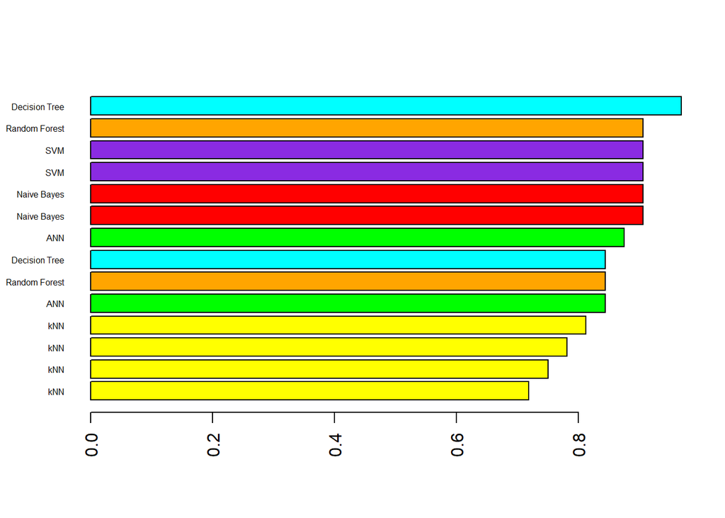